# 1. - Preparación de los datos para el tratamiento

```python
import pandas as pd
import numpy as np
import seaborn as sns
from matplotlib import pyplot as plt
import plotly.express as px
from sklearn.impute import KNNImputer
import scipy.stats as ss
import warnings
import sys
sys.path.append('../src')  # Asegúrate de que ../src es la carpeta donde está Funciones_Ayuda.py
import funciones as f  # Ahora debería importarse correctamente
sys.path.remove('../src')
from scipy.stats import chi2_contingency

sys.path.append('../src')  # Asegúrate de que ../src es la carpeta donde está Funciones_Ayuda.py
import funciones as f  # Ahora debería importarse correctamente
sys.path.remove('../src') ### MÓDULO CON FUNCIONES QUE VOY A USAR

warnings.filterwarnings("ignore")

## Configuro la visualización de mis datasets
pd.set_option('display.max_columns', 500)
pd.set_option('display.max_rows', 500)
```

```python
# Ruta de los archivos
ruta_categoricas_visualizacion = '../data/variables/lista_categoricas_visualizacion.txt'
ruta_categoricas_definitivo = '../data/variables/lista_categoricas_definitivo.txt'
ruta_deleted_variables = '../data/variables/deleted_variables.txt'

# Leer las listas desde los archivos
with open(ruta_categoricas_visualizacion, 'r') as fh:  # 'fh' para no sobrescribir el módulo 'f' (funciones)
    lista_categoricas_visualizacion = [line.strip() for line in fh]

with open(ruta_categoricas_definitivo, 'r') as fh:  # 'fh' para no sobrescribir el módulo 'f' (funciones)
    lista_categoricas_definitivo = [line.strip() for line in fh]

with open(ruta_deleted_variables, 'r') as fh:  # 'fh' para no sobrescribir el módulo 'f' (funciones)
    deleted_variables = [line.strip() for line in fh]

# Imprimir las listas para verificar
print("Lista Categoricas Visualizacion:", lista_categoricas_visualizacion)
print("Lista Categoricas Definitivo:", lista_categoricas_definitivo)
print("Deleted Variables:", deleted_variables)
```

```
Lista Categoricas Visualizacion: ['WALLSMATERIAL_MODE', 'HOUSETYPE_MODE', 'EMERGENCYSTATE_MODE', 'OCCUPATION_TYPE', 'NAME_TYPE_SUITE', 'NAME_CONTRACT_TYPE', 'CODE_GENDER', 'FLAG_OWN_CAR', 'FLAG_OWN_REALTY', 'WEEKDAY_APPR_PROCESS_START', 'ORGANIZATION_TYPE', 'NAME_HOUSING_TYPE', 'NAME_FAMILY_STATUS',…
Lista Categoricas Definitivo: ['WALLSMATERIAL_MODE', 'HOUSETYPE_MODE', 'EMERGENCYSTATE_MODE', 'OCCUPATION_TYPE', 'NAME_TYPE_SUITE', 'NAME_CONTRACT_TYPE', 'CODE_GENDER', 'FLAG_OWN_CAR', 'FLAG_OWN_REALTY', 'WEEKDAY_APPR_PROCESS_START', 'ORGANIZATION_TYPE', 'NAME_HOUSING_TYPE', 'NAME_FAMILY_STATUS', 'N…
Deleted Variables: ['COMMONAREA_MEDI', 'COMMONAREA_AVG', 'COMMONAREA_MODE', 'NONLIVINGAPARTMENTS_MODE', 'NONLIVINGAPARTMENTS_AVG', 'NONLIVINGAPARTMENTS_MEDI', 'FONDKAPREMONT_MODE', 'LIVINGAPARTMENTS_MODE', 'LIVINGAPARTMENTS_AVG', 'LIVINGAPARTMENTS_MEDI', 'FLOORSMIN_AVG', 'FLOORSMIN_MODE', 'FLOORSMIN…
```

```python
df_loan = pd.read_csv('../data/raw_data/application_data.csv')
```

```python
df_loan.dtypes.sort_values().to_frame('tipo').groupby('tipo').size().to_frame('cantidad').reset_index()
```

|  | tipo | cantidad |
| --- | --- | --- |
| 0 | int64 | 41 |
| 1 | float64 | 65 |
| 2 | object | 16 |

```python
df_loan = df_loan.drop(columns=deleted_variables, errors='ignore') ## errors= ignore sirve para que si hay columans que no están en el df se siga ejecutando
df_loan.dtypes.sort_values().to_frame('tipo').groupby('tipo').size().to_frame('cantidad').reset_index()
```

|  | tipo | cantidad |
| --- | --- | --- |
| 0 | int64 | 41 |
| 1 | float64 | 50 |
| 2 | object | 15 |

# 1.1. - Separación en train y test

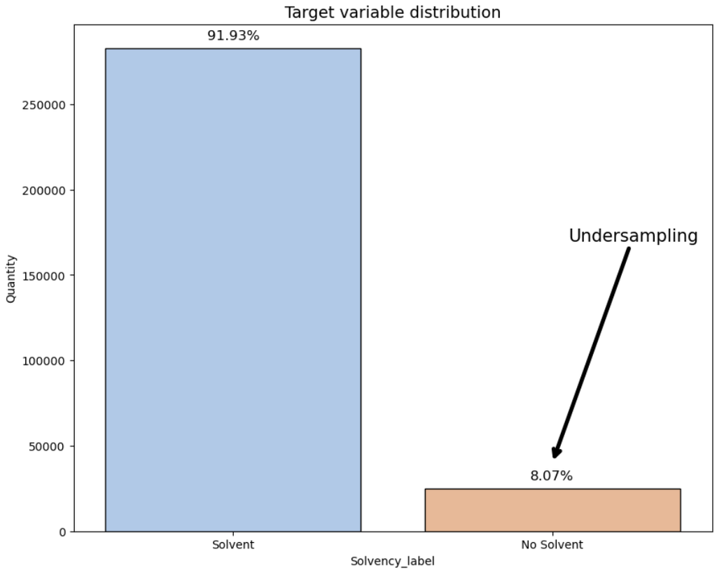

ref: NOTEBOOK: 01_Exploración_general

```python
from sklearn.model_selection import train_test_split

## Como tenemos un dataset con undersampling, vamos aplicar stratify para que la proporción se
## mantenga
x_train, x_test, y_train, y_test = train_test_split(df_loan.drop('TARGET', axis=1),
                                                    df_loan['TARGET'],
                                                    stratify=df_loan['TARGET'],
                                                    test_size=0.2,
                                                    random_state=123)  # semilla para que el split sea reproducible

df_loan_train = pd.concat([x_train, y_train], axis=1)
df_loan_test = pd.concat([x_test, y_test], axis=1)
```

```python
## Comprobación de que se han mantenido las distribuciones
print('== Train\n', df_loan_train['TARGET'].value_counts(normalize=True))
print('== Test\n', df_loan_test['TARGET'].value_counts(normalize=True))
df_loan_train.head()
```

```
== Train
 TARGET
0    0.919271
1    0.080729
Name: proportion, dtype: float64
== Test
 TARGET
0    0.919272
1    0.080728
Name: proportion, dtype: float64
```

|  | SK_ID_CURR | NAME_CONTRACT_TYPE | CODE_GENDER | FLAG_OWN_CAR | FLAG_OWN_REALTY | CNT_CHILDREN | AMT_INCOME_TOTAL | AMT_CREDIT | AMT_ANNUITY | AMT_GOODS_PRICE | NAME_TYPE_SUITE | NAME_INCOME_TYPE | NAME_EDUCATION_TYPE | NAME_FAMILY_STATUS | NAME_HOUSING_TYPE | REGION_POPULATION_RELATIVE | DAYS_BIRTH | DAYS_EMPLOYED | DAYS_REGISTRATION | DAYS_ID_PUBLISH | OWN_CAR_AGE | FLAG_MOBIL | FLAG_EMP_PHONE | FLAG_WORK_PHONE | FLAG_CONT_MOBILE | FLAG_PHONE | FLAG_EMAIL | OCCUPATION_TYPE | CNT_FAM_MEMBERS | … |
| --- | --- | --- | --- | --- | --- | --- | --- | --- | --- | --- | --- | --- | --- | --- | --- | --- | --- | --- | --- | --- | --- | --- | --- | --- | --- | --- | --- | --- | --- | --- |
| 305637 | 454112 | Cash loans | M | Y | Y | 0 | 135000.0 | 1061599.5 | 31171.5 | 927000.0 | Spouse, partner | Working | Secondary / secondary special | Married | House / apartment | 0.022625 | -18074 | -1102 | -7782.0 | -1615 | 9.0 | 1 | 1 | 1 | 1 | 1 | 0 | Drivers | 2.0 | … |
| 152596 | 276860 | Cash loans | M | N | Y | 0 | 216000.0 | 760131.0 | 28057.5 | 634500.0 | Unaccompanied | Working | Secondary / secondary special | Married | House / apartment | 0.028663 | -19562 | -6129 | -9254.0 | -3116 | NaN | 1 | 1 | 0 | 1 | 0 | 0 | Laborers | 2.0 | … |
| 64100 | 174331 | Cash loans | F | N | Y | 0 | 247500.0 | 675000.0 | 21906.0 | 675000.0 | Unaccompanied | Working | Secondary / secondary special | Married | House / apartment | 0.026392 | -15775 | -1294 | -9887.0 | -4038 | NaN | 1 | 1 | 0 | 1 | 0 | 0 | Security staff | 2.0 | … |
| 24351 | 128326 | Cash loans | M | N | Y | 0 | 189000.0 | 355536.0 | 18283.5 | 270000.0 | Unaccompanied | Working | Secondary / secondary special | Civil marriage | House / apartment | 0.010276 | -21145 | -13389 | -2294.0 | -4142 | NaN | 1 | 1 | 0 | 1 | 0 | 0 | Laborers | 2.0 | … |
| 118194 | 237052 | Cash loans | F | N | Y | 0 | 85500.0 | 99000.0 | 9774.0 | 99000.0 | Unaccompanied | Pensioner | Secondary / secondary special | Separated | House / apartment | 0.028663 | -22949 | 365243 | -398.0 | -4195 | NaN | 1 | 0 | 0 | 1 | 0 | 0 | NaN | 1.0 | … |

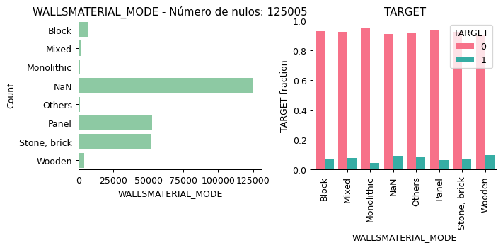

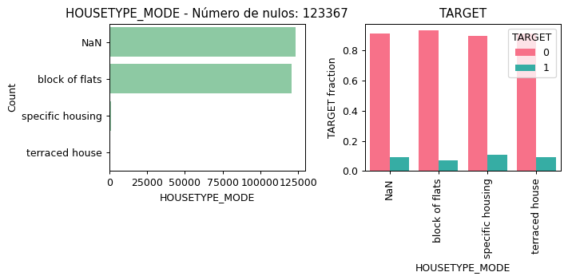

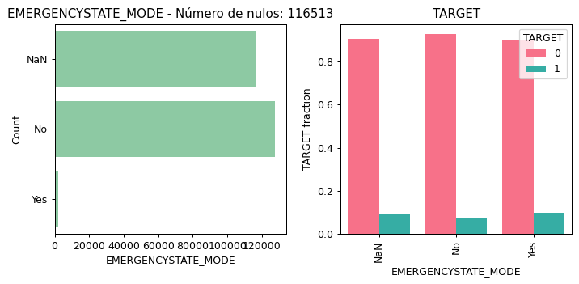

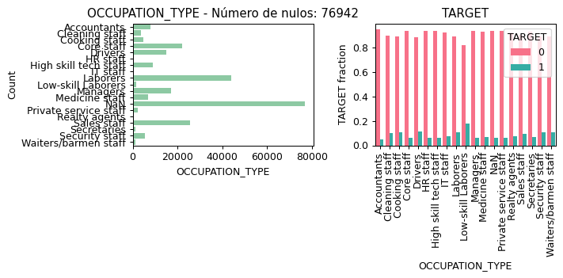

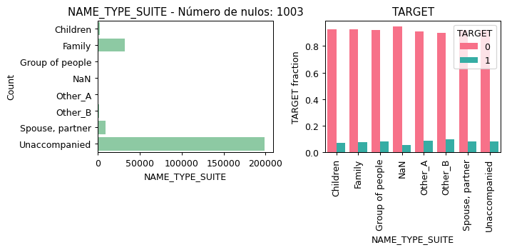

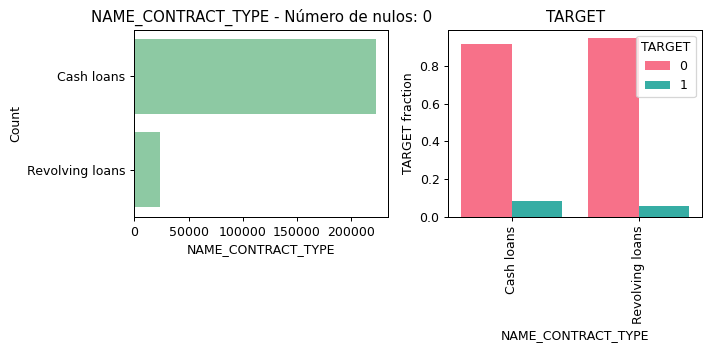

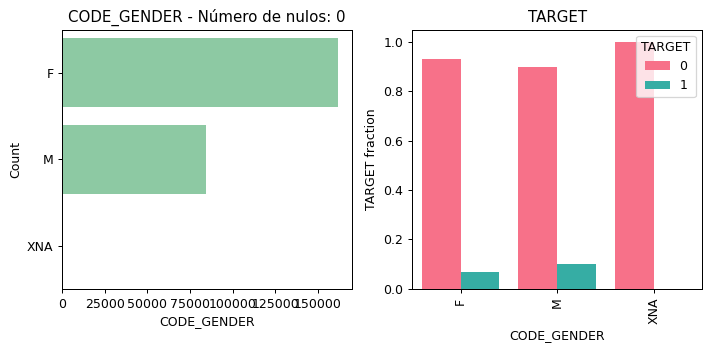

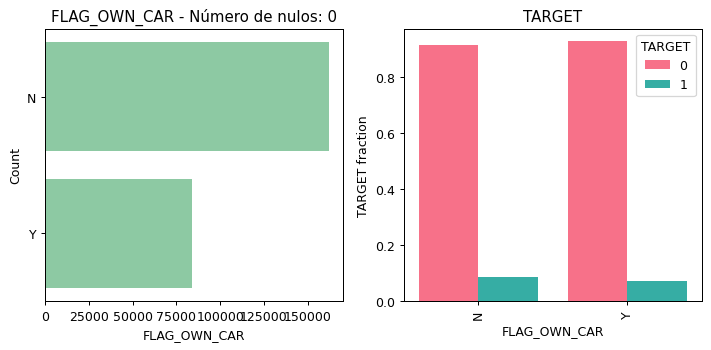

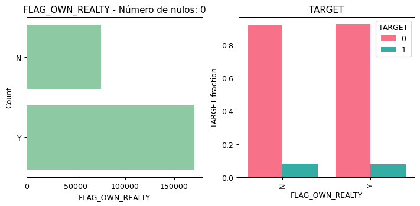

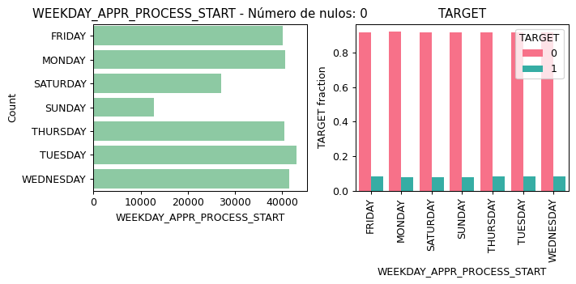

[figure not shown]

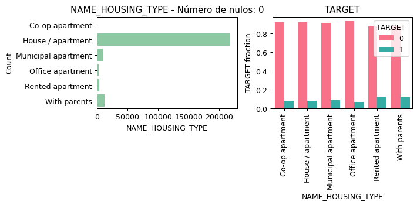

[51 more figures not shown]

```python
# Ejemplo de uso en el bucle
for i in lista_categoricas_visualizacion:
    if i != 'TARGET':
        f.plot_feature(df_loan_train, col_name=i, isContinuous=False, target='TARGET')

    plt.show()  ## para que según se van generando vayan apareciendo
```

### Inferencias

Relación entre género y dificultad de pago: Los hombres suelen mostrar una mayor dificultad para devolver los préstamos en comparación con las mujeres, lo que puede ser un indicador relevante en los modelos de riesgo crediticio.

Tipo de préstamo y riesgo: Los préstamos en efectivo (Cash loans) están más asociados con la posibilidad de impago, lo que sugiere que este tipo de financiamiento puede tener un perfil de mayor riesgo.

Número de hijos (CNT_CHILDREN): Los solicitantes sin hijos tienen una mayor probabilidad de cumplir con los pagos en comparación con aquellos que tienen hijos, lo que podría reflejar una mayor estabilidad financiera en este grupo.

Zona de residencia (REGION_RATING_CLIENT_W_CITY): Existe una fuerte correlación entre la zona en la que viven los clientes y la probabilidad de impago. La calificación "3" para la región es donde se observa el mayor riesgo de incumplimiento, lo que podría estar relacionado con factores socioeconómicos específicos de estas áreas.

```python
columnas_continuas = [col for col in df_loan_train.columns if col not in lista_categoricas_visualizacion]
print(columnas_continuas)
```

```
['SK_ID_CURR', 'AMT_INCOME_TOTAL', 'AMT_CREDIT', 'AMT_ANNUITY', 'AMT_GOODS_PRICE', 'REGION_POPULATION_RELATIVE', 'DAYS_BIRTH', 'DAYS_EMPLOYED', 'DAYS_REGISTRATION', 'DAYS_ID_PUBLISH', 'EXT_SOURCE_1', 'EXT_SOURCE_2', 'EXT_SOURCE_3', 'APARTMENTS_AVG', 'BASEMENTAREA_AVG', 'YEARS_BEGINEXPLUATATION_AVG',…
```

[figure not shown]

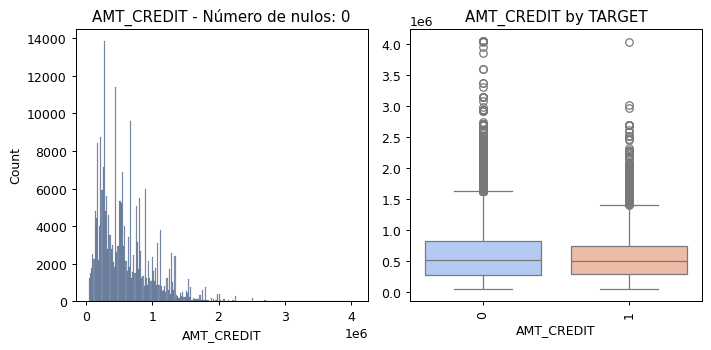

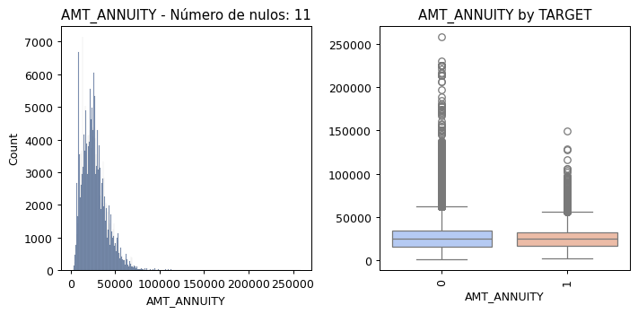

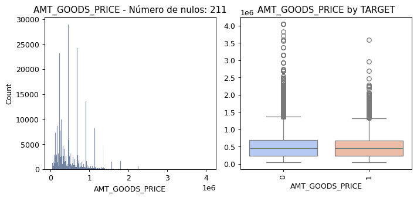

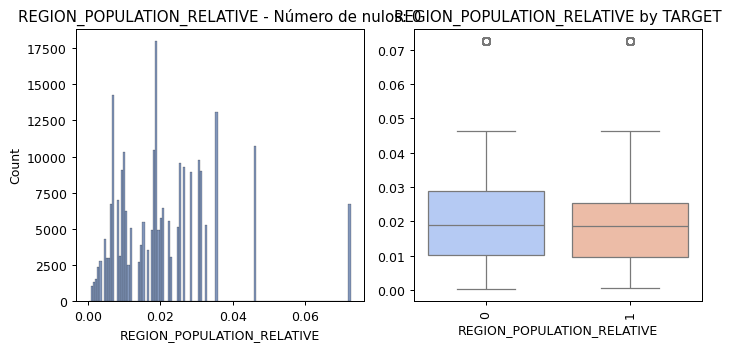

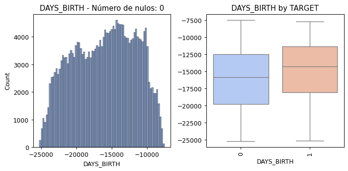

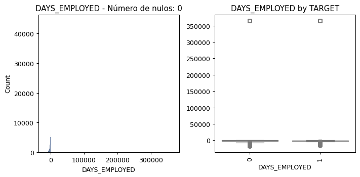

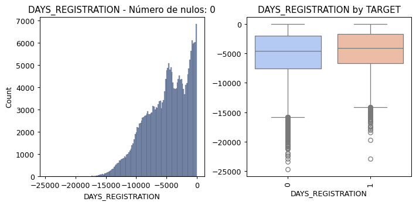

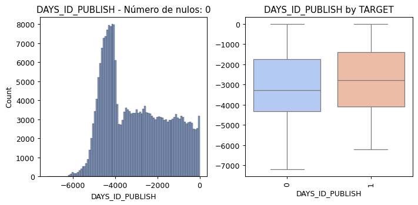

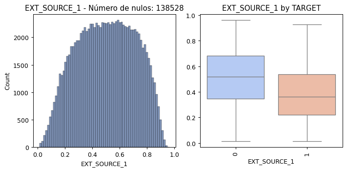

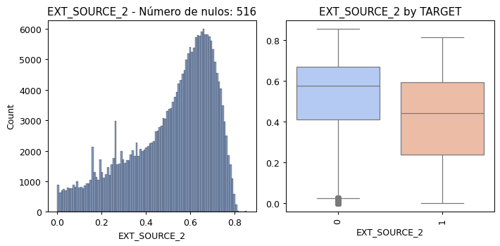

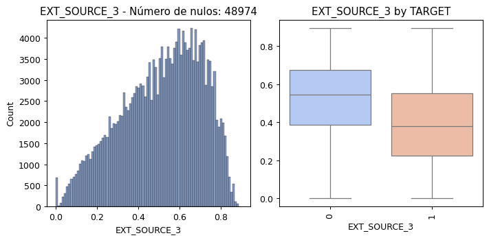

[29 more figures not shown]

```python
### Distribuación de las variables respecto al target
for i in columnas_continuas:
    if  i!='TARGET' and i!= 'SK_ID_CURR':
        f.plot_feature(df_loan_train, col_name=i, isContinuous=True, target='TARGET')

    plt.show()
```

### Inferencia

La edad del cliente, medida a través de la variable DAYS_BIRTH, se muestra como un factor altamente relevante en la capacidad de pago. Los datos reflejan que los clientes con dificultades para devolver el préstamo tienen una media de edad significativamente menor, con rangos intercuartílicos también más bajos. Esto sugiere que la juventud podría estar asociada con un mayor riesgo de impago.

En cuanto a DAYS_LAST_PHONE_CHANGE, existe una relación notable: aquellos clientes que han cambiado su número de teléfono móvil más recientemente tienen más probabilidades de presentar dificultades de pago. Esto podría interpretarse como un indicio de inestabilidad o cambios recientes en su situación personal.

Algo parecido pasa con la variable DAYS_ID_PUBLISH: los clientes que han actualizado su documento de identidad en fechas más cercanas a la solicitud del préstamo presentan más dificultades de pago (de media lo cambiaron 2.728 días antes de la solicitud, frente a 3.018 los que sí pagan). Igual que con el teléfono, podría interpretarse como un indicio de cambios recientes en su situación personal.

Finalmente, las puntuaciones más bajas en las variables externas EXT_SOURCE_* están claramente correlacionadas con un mayor riesgo de impago. Estas puntuaciones, provenientes de fuentes externas, reflejan de forma consistente la probabilidad de dificultades financieras, reafirmando su importancia en el análisis.

# 2. - Tratamiento variables continuas

```python
## Almacenamos en una lista aquellas variables que son continuas
lista_continuas = [col for col in df_loan_train.columns if col not in lista_categoricas_definitivo]
lista_continuas.remove('SK_ID_CURR') ## elimino el ID
lista_continuas.remove('TARGET')
df_loan_train[lista_continuas].head()
```

|  | CNT_CHILDREN | AMT_INCOME_TOTAL | AMT_CREDIT | AMT_ANNUITY | AMT_GOODS_PRICE | REGION_POPULATION_RELATIVE | DAYS_BIRTH | DAYS_EMPLOYED | DAYS_REGISTRATION | DAYS_ID_PUBLISH | OWN_CAR_AGE | CNT_FAM_MEMBERS | HOUR_APPR_PROCESS_START | EXT_SOURCE_1 | EXT_SOURCE_2 | EXT_SOURCE_3 | APARTMENTS_AVG | BASEMENTAREA_AVG | YEARS_BEGINEXPLUATATION_AVG | ELEVATORS_AVG | ENTRANCES_AVG | FLOORSMAX_AVG | LANDAREA_AVG | LIVINGAREA_AVG | NONLIVINGAREA_AVG | APARTMENTS_MODE | BASEMENTAREA_MODE | YEARS_BEGINEXPLUATATION_MODE | ELEVATORS_MODE | … |
| --- | --- | --- | --- | --- | --- | --- | --- | --- | --- | --- | --- | --- | --- | --- | --- | --- | --- | --- | --- | --- | --- | --- | --- | --- | --- | --- | --- | --- | --- | --- |
| 305637 | 0 | 135000.0 | 1061599.5 | 31171.5 | 927000.0 | 0.022625 | -18074 | -1102 | -7782.0 | -1615 | 9.0 | 2.0 | 9 | NaN | 0.433017 | NaN | 0.1237 | NaN | 0.9896 | 0.00 | 0.0690 | 0.3750 | NaN | 0.1119 | NaN | 0.1261 | NaN | 0.9896 | 0.0000 | … |
| 152596 | 0 | 216000.0 | 760131.0 | 28057.5 | 634500.0 | 0.028663 | -19562 | -6129 | -9254.0 | -3116 | NaN | 2.0 | 15 | NaN | 0.674165 | 0.363945 | 0.0753 | 0.0507 | 0.9871 | 0.08 | 0.0690 | 0.3333 | 0.0633 | 0.0728 | 0.0006 | 0.0767 | 0.0526 | 0.9871 | 0.0806 | … |
| 64100 | 0 | 247500.0 | 675000.0 | 21906.0 | 675000.0 | 0.026392 | -15775 | -1294 | -9887.0 | -4038 | NaN | 2.0 | 14 | NaN | 0.651897 | 0.508287 | NaN | NaN | NaN | NaN | NaN | NaN | NaN | NaN | NaN | NaN | NaN | NaN | NaN | … |
| 24351 | 0 | 189000.0 | 355536.0 | 18283.5 | 270000.0 | 0.010276 | -21145 | -13389 | -2294.0 | -4142 | NaN | 2.0 | 10 | NaN | 0.600732 | 0.121408 | 0.1959 | 0.1640 | 0.9930 | 0.20 | 0.1724 | 0.3750 | 0.0953 | 0.2764 | 0.0000 | 0.1996 | 0.1702 | 0.9930 | 0.2014 | … |
| 118194 | 0 | 85500.0 | 99000.0 | 9774.0 | 99000.0 | 0.028663 | -22949 | 365243 | -398.0 | -4195 | NaN | 1.0 | 12 | NaN | 0.479856 | 0.771362 | 0.0567 | 0.0866 | 0.9846 | 0.00 | 0.1724 | 0.1667 | 0.0502 | 0.0676 | 0.0000 | 0.0578 | 0.0899 | 0.9846 | 0.0000 | … |

## 2.1. - Outliers

```python
def get_deviation_of_mean_perc(pd_loan, list_var_continuous, target, multiplier):
    ### La dejo aquí porque me da problemas al pasarla al .py
    """
    Devuelve un DataFrame que muestra el porcentaje de valores que exceden el intervalo de confianza,
    junto con la distribución del target para esos valores.

    :param pd_loan: DataFrame con los datos a analizar.
    :param list_var_continuous: Lista de variables continuas a analizar.
    :param target: Variable objetivo para analizar la distribución de categorías.
    :param multiplier: Factor multiplicativo para determinar el rango de confianza (media ± multiplier * std).
    :return: DataFrame con las proporciones del target para los valores fuera del rango de confianza.
    """
    # DataFrame para almacenar los resultados finales
    pd_final = pd.DataFrame()

    # Obtener las categorías únicas del target para usarlas en las columnas
    target_categories = pd_loan[target].unique()

    # Iterar sobre cada variable continua de la lista
    for i in list_var_continuous:
        # Calcular la media y desviación estándar de la variable
        series_mean = pd_loan[i].mean()
        series_std = pd_loan[i].std()

        # Determinar los límites del rango de confianza
        std_amp = multiplier * series_std
        left = series_mean - std_amp  # Límite inferior
        right = series_mean + std_amp  # Límite superior
        size_s = pd_loan[i].size  # Tamaño total de la serie (número de valores [filas])

        # Calcular el porcentaje de valores fuera del rango de confianza
        perc_excess = pd_loan[i][(pd_loan[i] < left) | (pd_loan[i] > right)].size / size_s

        # Si hay valores fuera del rango de confianza, analizar el target
        if perc_excess > 0:
            # Filtrar el target para los valores fuera del rango de confianza
            outliers = pd_loan[target][(pd_loan[i] < left) | (pd_loan[i] > right)]

            # Calcular las proporciones de cada categoría del target
            proportions = outliers.value_counts(normalize=True)

            # Crear un DataFrame temporal con estas proporciones
            temp_df = proportions.to_frame().T.reset_index(drop=True)

            # Asignar nombres a las columnas basados en las categorías del target
            temp_df.columns = [str(cat) for cat in proportions.index]

            # Añadir información adicional al DataFrame temporal
            temp_df['variable'] = i  # Nombre de la variable continua
            temp_df['sum_outlier_values'] = outliers.size  # Total de valores fuera del rango
            temp_df['porcentaje_sum_null_values'] = perc_excess  # Porcentaje de valores fuera del rango

            # Concatenar los resultados de esta variable al DataFrame final
            pd_final = pd.concat([pd_final, temp_df], axis=0).reset_index(drop=True)

    # Si no se encontró ningún valor fuera del rango, mostrar mensaje
    if pd_final.empty:
        print('No existen variables con valores fuera del rango de confianza')

    return pd_final.sort_values(by='sum_outlier_values', ascending=False)
```

```python
df_outliers = get_deviation_of_mean_perc(df_loan_train, lista_continuas, target='TARGET', multiplier=3)
df_outliers
```

|  | 0 | 1 | variable | sum_outlier_values | porcentaje_sum_null_values |
| --- | --- | --- | --- | --- | --- |
| 45 | 0.921827 | 0.078173 | AMT_REQ_CREDIT_BUREAU_WEEK | 6831 | 0.027767 |
| 5 | 0.959733 | 0.040267 | REGION_POPULATION_RELATIVE | 6730 | 0.027357 |
| 39 | 0.878288 | 0.121712 | DEF_30_CNT_SOCIAL_CIRCLE | 5398 | 0.021942 |
| 38 | 0.911224 | 0.088776 | OBS_30_CNT_SOCIAL_CIRCLE | 4900 | 0.019918 |
| 40 | 0.911097 | 0.088903 | OBS_60_CNT_SOCIAL_CIRCLE | 4758 | 0.019341 |
| 0 | 0.898181 | 0.101819 | CNT_CHILDREN | 3408 | 0.013853 |
| 4 | 0.959916 | 0.040084 | AMT_GOODS_PRICE | 3318 | 0.013487 |
| 8 | 0.899186 | 0.100814 | CNT_FAM_MEMBERS | 3194 | 0.012983 |
| 41 | 0.870531 | 0.129469 | DEF_60_CNT_SOCIAL_CIRCLE | 3105 | 0.012622 |
| 48 | 0.911004 | 0.088996 | AMT_REQ_CREDIT_BUREAU_YEAR | 2708 | 0.011008 |
| 22 | 0.949329 | 0.050671 | ELEVATORS_MODE | 2684 | 0.010910 |
| 7 | 0.916479 | 0.083521 | OWN_CAR_AGE | 2670 | 0.010853 |
| 26 | 0.945673 | 0.054327 | LIVINGAREA_MODE | 2669 | 0.010849 |
| 37 | 0.956044 | 0.043956 | TOTALAREA_MODE | 2639 | 0.010727 |
| 2 | 0.958988 | 0.041012 | AMT_CREDIT | 2609 | 0.010605 |
| 35 | 0.948968 | 0.051032 | LIVINGAREA_MEDI | 2567 | 0.010435 |
| 46 | 0.948478 | 0.051522 | AMT_REQ_CREDIT_BUREAU_MON | 2562 | 0.010414 |
| 17 | 0.947904 | 0.052096 | LIVINGAREA_AVG | 2553 | 0.010378 |
| 28 | 0.949979 | 0.050021 | APARTMENTS_MEDI | 2419 | 0.009833 |
| 19 | 0.948505 | 0.051495 | APARTMENTS_MODE | 2408 | 0.009788 |
| 10 | 0.950358 | 0.049642 | APARTMENTS_AVG | 2377 | 0.009662 |
| 3 | 0.960951 | 0.039049 | AMT_ANNUITY | 2356 | 0.009577 |
| 33 | 0.957515 | 0.042485 | FLOORSMAX_MEDI | 2189 | 0.008898 |
| 24 | 0.958768 | 0.041232 | FLOORSMAX_MODE | 2110 | 0.008577 |
| 15 | 0.957355 | 0.042645 | FLOORSMAX_AVG | 2087 | 0.008483 |
| 27 | 0.949058 | 0.050942 | NONLIVINGAREA_MODE | 1963 | 0.007979 |
| 36 | 0.948692 | 0.051308 | NONLIVINGAREA_MEDI | 1949 | 0.007923 |
| 13 | 0.953775 | 0.046225 | ELEVATORS_AVG | 1947 | 0.007914 |
| 18 | 0.948454 | 0.051546 | NONLIVINGAREA_AVG | 1940 | 0.007886 |
| 31 | 0.953981 | 0.046019 | ELEVATORS_MEDI | 1934 | 0.007862 |
| 47 | 0.917163 | 0.082837 | AMT_REQ_CREDIT_BUREAU_QRT | 1847 | 0.007508 |
| 32 | 0.938582 | 0.061418 | ENTRANCES_MEDI | 1791 | 0.007280 |
| 14 | 0.938833 | 0.061167 | ENTRANCES_AVG | 1782 | 0.007244 |
| 23 | 0.938244 | 0.061756 | ENTRANCES_MODE | 1765 | 0.007175 |
| 25 | 0.935972 | 0.064028 | LANDAREA_MODE | 1718 | 0.006984 |
| 34 | 0.938596 | 0.061404 | LANDAREA_MEDI | 1710 | 0.006951 |
| 16 | 0.935252 | 0.064748 | LANDAREA_AVG | 1668 | 0.006780 |
| 20 | 0.944745 | 0.055255 | BASEMENTAREA_MODE | 1665 | 0.006768 |
| 29 | 0.947937 | 0.052063 | BASEMENTAREA_MEDI | 1575 | 0.006402 |
| 11 | 0.949077 | 0.050923 | BASEMENTAREA_AVG | 1571 | 0.006386 |
| 43 | 0.915881 | 0.084119 | AMT_REQ_CREDIT_BUREAU_HOUR | 1272 | 0.005171 |
| 44 | 0.905772 | 0.094228 | AMT_REQ_CREDIT_BUREAU_DAY | 1178 | 0.004788 |
| 6 | 0.958403 | 0.041597 | DAYS_REGISTRATION | 601 | 0.002443 |
| 12 | 0.917431 | 0.082569 | YEARS_BEGINEXPLUATATION_AVG | 545 | 0.002215 |
| 21 | 0.915414 | 0.084586 | YEARS_BEGINEXPLUATATION_MODE | 532 | 0.002163 |
| 42 | 0.965974 | 0.034026 | DAYS_LAST_PHONE_CHANGE | 529 | 0.002150 |
| 9 | 0.897638 | 0.102362 | HOUR_APPR_PROCESS_START | 508 | 0.002065 |
| 30 | 0.913386 | 0.086614 | YEARS_BEGINEXPLUATATION_MEDI | 508 | 0.002065 |
| 1 | 0.938095 | 0.061905 | AMT_INCOME_TOTAL | 210 | 0.000854 |

Implicaciones

1. Relación Entre Outliers y Categorías del Objetivo
   - Si los valores extremos tienen proporciones significativamente diferentes de las categorías del objetivo, podrían ser informativos para el modelo. Por ejemplo, variables como DEF_30_CNT_SOCIAL_CIRCLE tienen un 12.2% de 1 en los outliers, lo que podría ser relevante.
   - Por otro lado, si las proporciones son similares a las del conjunto completo, los outliers podrían ser simplemente ruido.
2. Impacto de los Outliers en el Modelo
   - Las variables con altos porcentajes de outliers pueden sesgar el modelo si no se tratan adecuadamente.
   - Por ejemplo, en variables como AMT_REQ_CREDIT_BUREAU_WEEK, los outliers representan un 2.8% de los datos, lo que podría influir desproporcionadamente en modelos sensibles a valores extremos (e.g., regresión lineal).

Opciones de tratamiento de outliers:

1. Winsorización: Limitar los valores extremos al percentil más cercano (e.g., 1% y 99%). Útil cuando los outliers no aportan información adicional pero podrían distorsionar el modelo.
2. Eliminación de Outliers: Eliminar filas que contienen outliers si representan errores de medición o no aportan valor. Usar criterios como el rango intercuartílico (IQR) para definir qué valores eliminar.
3. Imputación de Valores Extremos: Sustituir los valores extremos por la mediana, el valor más cercano al límite del rango o incluso predicciones basadas en otras variables.
4. Dejar los Outliers Intactos: Si los outliers aportan información relevante para el modelo (e.g., diferencian claramente entre categorías del objetivo), podrían mantenerse, pero asegurando que el modelo sea robusto (e.g., árboles de decisión, Random Forest).

Conclusión:

Por el momento no voy a realizar un tratamiento de los outliers, ya que parece no son muchos y además no tienen un impacto significativo. Además, como todavía no se ha determinado el tipo de modelo que se va a utilizar en este proyecto, no se si va a ser un modelo que funcionaría mejor con los outliers. En caso de que más tarde hubiera que corregir algunos de ellos seguramente autlizaré el método winsorize, permitiendome reemplazarlos por los valores más cercanos dentro del rango que determine, por ejemplo podría ser el percentil 1.

```python
## Aunque he decidido no tratar los outliers en general, he incorporado un criterio específico para identificar
## un subconjunto de ellos que podrían ser relevantes para mejorar la detección de clientes no solventes.
## Para ello, defino un **umbral de mejora** basado en el porcentaje inicial de casos positivos ajustado
## en un 25%. Este criterio asegura que solo se consideren aquellos outliers que superen este umbral, ya
## que podrían aportar información valiosa para el modelo.

## Este enfoque permite mantener los outliers que podrían ser útiles, mientras que los restantes no se tratan por
## ahora. Cabe destacar que, dado que representan una proporción pequeña de los datos, existe el riesgo de que
## estos valores contribuyan al overfitting en ciertos modelos. En ese caso, se podría revisar este criterio y
## ajustar o eliminar los outliers problemáticos.

umbral_mejora_outliers = 0.0807 *1.25
df_outliers_mantener = df_outliers[df_outliers['1'] > umbral_mejora_outliers]
outliers_mantenidos = df_outliers_mantener['variable'].tolist()

df_outliers_mantener
```

|  | 0 | 1 | variable | sum_outlier_values | porcentaje_sum_null_values |
| --- | --- | --- | --- | --- | --- |
| 39 | 0.878288 | 0.121712 | DEF_30_CNT_SOCIAL_CIRCLE | 5398 | 0.021942 |
| 0 | 0.898181 | 0.101819 | CNT_CHILDREN | 3408 | 0.013853 |
| 41 | 0.870531 | 0.129469 | DEF_60_CNT_SOCIAL_CIRCLE | 3105 | 0.012622 |
| 9 | 0.897638 | 0.102362 | HOUR_APPR_PROCESS_START | 508 | 0.002065 |

# 2.2. - Valores faltantenes (NaN)

## 2.2.1. - Análisis

```python
def get_percent_null_values_target(pd_loan, list_var_continuous, target):

    pd_final = pd.DataFrame()
    for i in list_var_continuous:
        if pd_loan[i].isnull().sum()>0:
            pd_concat_percent = pd.DataFrame(pd_loan[target][pd_loan[i].isnull()]\
                                            .value_counts(normalize=True)).T
            pd_concat_percent['variable'] = i
            pd_concat_percent['sum_null_values'] = pd_loan[i].isnull().sum()
            pd_concat_percent['porcentaje_sum_null_values'] = pd_loan[i].isnull().sum()/pd_loan.shape[0]
            pd_final = pd.concat([pd_final, pd_concat_percent], axis=0).reset_index(drop=True)

    if pd_final.empty:
        print('No existen variables con valores nulos')

    return pd_final.sort_values(by='sum_null_values', ascending=False)
```

```python
get_percent_null_values_target(df_loan_train,lista_continuas,'TARGET')
```

| TARGET | 0 | variable | sum_null_values | porcentaje_sum_null_values | 1 |
| --- | --- | --- | --- | --- | --- |
| 2 | 0.914944 | OWN_CAR_AGE | 162329 | 0.659853 | 0.085056 |
| 22 | 0.911949 | LANDAREA_MODE | 146029 | 0.593595 | 0.088051 |
| 31 | 0.911949 | LANDAREA_MEDI | 146029 | 0.593595 | 0.088051 |
| 13 | 0.911949 | LANDAREA_AVG | 146029 | 0.593595 | 0.088051 |
| 26 | 0.911016 | BASEMENTAREA_MEDI | 143880 | 0.584859 | 0.088984 |
| 8 | 0.911016 | BASEMENTAREA_AVG | 143880 | 0.584859 | 0.088984 |
| 17 | 0.911016 | BASEMENTAREA_MODE | 143880 | 0.584859 | 0.088984 |
| 4 | 0.914595 | EXT_SOURCE_1 | 138528 | 0.563104 | 0.085405 |
| 33 | 0.909864 | NONLIVINGAREA_MEDI | 135617 | 0.551271 | 0.090136 |
| 24 | 0.909864 | NONLIVINGAREA_MODE | 135617 | 0.551271 | 0.090136 |
| 15 | 0.909864 | NONLIVINGAREA_AVG | 135617 | 0.551271 | 0.090136 |
| 19 | 0.909222 | ELEVATORS_MODE | 131001 | 0.532507 | 0.090778 |
| 28 | 0.909222 | ELEVATORS_MEDI | 131001 | 0.532507 | 0.090778 |
| 10 | 0.909222 | ELEVATORS_AVG | 131001 | 0.532507 | 0.090778 |
| 16 | 0.908756 | APARTMENTS_MODE | 124764 | 0.507154 | 0.091244 |
| 25 | 0.908756 | APARTMENTS_MEDI | 124764 | 0.507154 | 0.091244 |
| 7 | 0.908756 | APARTMENTS_AVG | 124764 | 0.507154 | 0.091244 |
| 11 | 0.908444 | ENTRANCES_AVG | 123739 | 0.502988 | 0.091556 |
| 29 | 0.908444 | ENTRANCES_MEDI | 123739 | 0.502988 | 0.091556 |
| 20 | 0.908444 | ENTRANCES_MODE | 123739 | 0.502988 | 0.091556 |
| 14 | 0.908792 | LIVINGAREA_AVG | 123356 | 0.501431 | 0.091208 |
| 32 | 0.908792 | LIVINGAREA_MEDI | 123356 | 0.501431 | 0.091208 |
| 23 | 0.908792 | LIVINGAREA_MODE | 123356 | 0.501431 | 0.091208 |
| 12 | 0.908375 | FLOORSMAX_AVG | 122325 | 0.497240 | 0.091625 |
| 30 | 0.908375 | FLOORSMAX_MEDI | 122325 | 0.497240 | 0.091625 |
| 21 | 0.908375 | FLOORSMAX_MODE | 122325 | 0.497240 | 0.091625 |
| 27 | 0.908192 | YEARS_BEGINEXPLUATATION_MEDI | 119935 | 0.487525 | 0.091808 |
| 18 | 0.908192 | YEARS_BEGINEXPLUATATION_MODE | 119935 | 0.487525 | 0.091808 |
| 9 | 0.908192 | YEARS_BEGINEXPLUATATION_AVG | 119935 | 0.487525 | 0.091808 |
| 34 | 0.907951 | TOTALAREA_MODE | 118643 | 0.482273 | 0.092049 |
| 6 | 0.907155 | EXT_SOURCE_3 | 48974 | 0.199075 | 0.092845 |
| 41 | 0.896709 | AMT_REQ_CREDIT_BUREAU_WEEK | 33391 | 0.135731 | 0.103291 |
| 39 | 0.896709 | AMT_REQ_CREDIT_BUREAU_HOUR | 33391 | 0.135731 | 0.103291 |
| 42 | 0.896709 | AMT_REQ_CREDIT_BUREAU_MON | 33391 | 0.135731 | 0.103291 |
| 43 | 0.896709 | AMT_REQ_CREDIT_BUREAU_QRT | 33391 | 0.135731 | 0.103291 |
| 40 | 0.896709 | AMT_REQ_CREDIT_BUREAU_DAY | 33391 | 0.135731 | 0.103291 |
| 44 | 0.896709 | AMT_REQ_CREDIT_BUREAU_YEAR | 33391 | 0.135731 | 0.103291 |
| 37 | 0.970443 | OBS_60_CNT_SOCIAL_CIRCLE | 812 | 0.003301 | 0.029557 |
| 38 | 0.970443 | DEF_60_CNT_SOCIAL_CIRCLE | 812 | 0.003301 | 0.029557 |
| 36 | 0.970443 | DEF_30_CNT_SOCIAL_CIRCLE | 812 | 0.003301 | 0.029557 |
| 35 | 0.970443 | OBS_30_CNT_SOCIAL_CIRCLE | 812 | 0.003301 | 0.029557 |
| 5 | 0.914729 | EXT_SOURCE_2 | 516 | 0.002097 | 0.085271 |
| 1 | 0.919431 | AMT_GOODS_PRICE | 211 | 0.000858 | 0.080569 |
| 0 | 1.000000 | AMT_ANNUITY | 11 | 0.000045 | NaN |
| 3 | 1.000000 | CNT_FAM_MEMBERS | 2 | 0.000008 | NaN |

### Inferencia de la tabla

Lo primero quiero aclarar que viendo la variable 'OWN_CAR_AGE', con un 66% de faltantes y un impacto en la predicción de la variable objetivo no muy alto, es candidata a ser eliminada. Pero la voy a dejar porque veo probable que exista algún tipo de relación entre la solvencia y esta variable. Ya sea porque una persona con un coche de 30 años es probable que no tenga poder adquisitivo para tener un buen sustituto. O por el otro lado, una persona que acaba de comprarse un coche habrá tenido que realizar una gran inversión de captial.

#### Selección de variables para KNN

La imputación por KNN (K-Nearest Neighbors) consiste en rellenar valores faltantes en un conjunto de datos utilizando los valores de los registros más similares, según una métrica de distancia (como la distancia euclidiana). El algoritmo identifica los 𝑘 vecinos más cercanos para cada registro con valores faltantes, basándose en las características disponibles, y utiliza sus valores (generalmente mediante un promedio ponderado, una moda, o una mediana) para imputar los datos faltantes. Este método es especialmente útil cuando las variables están correlacionadas y los patrones entre los datos permiten inferencias significativas, pero requiere escalamiento previo de los datos y puede ser computacionalmente costoso en conjuntos de datos grandes.

¿Qué considerar para usar KNN en imputación?

1. Tamaño y proporción de valores faltantes:
   - Problema: Si una columna tiene una alta proporción de valores faltantes (por ejemplo, más del 50%), KNN podría no ser efectivo, ya que no habría suficientes datos completos para inferir patrones. En este caso: Algunas variables, como OWN_CAR_AGE (66% faltantes) o LANDAREA_AVG (59%), tienen una proporción de valores faltantes muy alta. KNN no sería la mejor opción para estas variables. Variables como EXT_SOURCE_3 (20%) o AMT_REQ_CREDIT_BUREAU_WEEK (14%) tienen una proporción manejable, por lo que KNN podría ser adecuado.
2. Relación entre las variables:
   - Ventaja del KNN: Puede aprovechar patrones complejos en los datos para imputar valores faltantes basándose en la similitud con otros registros.
   - Problema: Si las variables no están correlacionadas entre sí o con las otras variables del dataset, KNN podría generar imputaciones poco fiables.
3. Escalamiento de los datos:
   - Importante: Antes de aplicar KNN, las variables deben estar normalizadas o estandarizadas, ya que KNN se basa en la distancia entre puntos.
4. Tamaño del dataset:
   - Problema: KNN es computacionalmente costoso para datasets grandes, ya que calcula distancias para cada registro faltante. Si el dataset es muy grande, podrías considerar una muestra.

```python
# Filtrar las columnas que comienzan con un prefijo específico
lista_KNN = [col for col in df_loan_train.columns if col.startswith("AMT_REQ_CREDIT_BUREAU_")]

# Mostrar las columnas filtradas
print(lista_KNN)
```

```
['AMT_REQ_CREDIT_BUREAU_HOUR', 'AMT_REQ_CREDIT_BUREAU_DAY', 'AMT_REQ_CREDIT_BUREAU_WEEK', 'AMT_REQ_CREDIT_BUREAU_MON', 'AMT_REQ_CREDIT_BUREAU_QRT', 'AMT_REQ_CREDIT_BUREAU_YEAR']
```